# exercise-10

Author

John Hinkle

## Preliminaries

```r
library(tidyverse) # tidyverse suite of packages
library(ggplot2) # for plotting
library(cowplot) # for making multi-panel figures
library(skimr) # for exploratory data analysis

d <- read_csv("https://raw.githubusercontent.com/difiore/ada-datasets/refs/heads/main/AVONETdataset1.csv")
# winnow dataset to the specified variables
d <- d |> select(Species1, Family1, Order1, Beak.Length_Culmen, Beak.Width, Beak.Depth, Tarsus.Length, Wing.Length, Tail.Length, Mass, Habitat, Migration, Trophic.Level, Trophic.Niche, Min.Latitude, Max.Latitude, Centroid.Latitude, Primary.Lifestyle, Range.Size)

skim(d)
```

Data summary

| Name | d |
| --- | --- |
| Number of rows | 11009 |
| Number of columns | 19 |
| _______________________ |  |
| Column type frequency: |  |
| character | 7 |
| numeric | 12 |
| ________________________ |  |
| Group variables | None |

**Variable type: character**

| skim_variable | n_missing | complete_rate | min | max | empty | n_unique | whitespace |
| --- | --- | --- | --- | --- | --- | --- | --- |
| Species1 | 0 | 1.00 | 9 | 36 | 0 | 11009 | 0 |
| Family1 | 0 | 1.00 | 7 | 18 | 0 | 243 | 0 |
| Order1 | 0 | 1.00 | 10 | 19 | 0 | 36 | 0 |
| Habitat | 98 | 0.99 | 4 | 14 | 0 | 11 | 0 |
| Trophic.Level | 5 | 1.00 | 8 | 9 | 0 | 4 | 0 |
| Trophic.Niche | 10 | 1.00 | 8 | 21 | 0 | 10 | 0 |
| Primary.Lifestyle | 0 | 1.00 | 6 | 11 | 0 | 5 | 0 |

**Variable type: numeric**

| skim_variable | n_missing | complete_rate | mean | sd | p0 | p25 | p50 | p75 | p100 | hist |
| --- | --- | --- | --- | --- | --- | --- | --- | --- | --- | --- |
| Beak.Length_Culmen | 0 | 1.00 | 26.36 | 24.39 | 4.50 | 14.70 | 19.90 | 28.50 | 414.20 | ▇▁▁▁▁ |
| Beak.Width | 0 | 1.00 | 6.58 | 5.15 | 0.70 | 3.60 | 5.00 | 7.70 | 88.90 | ▇▁▁▁▁ |
| Beak.Depth | 0 | 1.00 | 8.06 | 7.59 | 1.00 | 3.80 | 5.80 | 9.40 | 110.90 | ▇▁▁▁▁ |
| Tarsus.Length | 0 | 1.00 | 28.73 | 24.84 | 2.50 | 17.40 | 22.00 | 31.30 | 481.20 | ▇▁▁▁▁ |
| Wing.Length | 0 | 1.00 | 124.78 | 93.44 | 0.10 | 66.80 | 91.50 | 145.50 | 789.90 | ▇▂▁▁▁ |
| Tail.Length | 0 | 1.00 | 86.65 | 61.08 | 0.10 | 50.20 | 68.70 | 99.90 | 812.80 | ▇▁▁▁▁ |
| Mass | 0 | 1.00 | 267.15 | 1883.03 | 1.90 | 15.00 | 35.50 | 121.00 | 111000.00 | ▇▁▁▁▁ |
| Migration | 23 | 1.00 | 1.29 | 0.62 | 1.00 | 1.00 | 1.00 | 1.00 | 3.00 | ▇▁▁▁▁ |
| Min.Latitude | 57 | 0.99 | -6.44 | 22.37 | -85.58 | -21.22 | -7.15 | 8.07 | 68.08 | ▁▃▇▃▁ |
| Max.Latitude | 57 | 0.99 | 11.51 | 23.32 | -65.12 | -3.33 | 9.00 | 22.07 | 85.01 | ▁▃▇▂▁ |
| Centroid.Latitude | 57 | 0.99 | 2.95 | 22.07 | -71.04 | -9.73 | -0.22 | 15.28 | 78.43 | ▁▃▇▂▁ |
| Range.Size | 57 | 0.99 | 2578859.38 | 7629310.06 | 0.88 | 54052.87 | 416076.61 | 2187040.21 | 136304432.20 | ▇▁▁▁▁ |

# Challenge 1

## Step 1: Boxplots of log(**Mass**) in relation to **trophic level and migration behavior type**

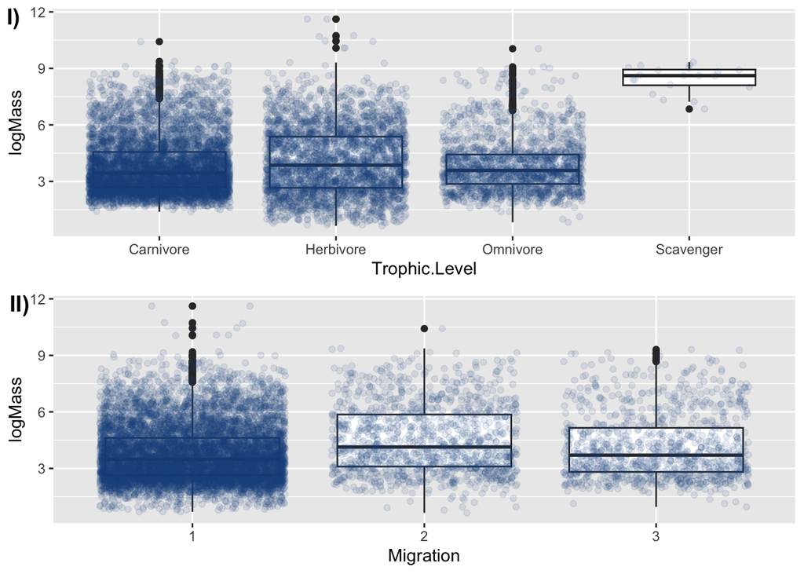

```r
d <- d |>
  mutate(Migration = as.factor(Migration)) |>
  mutate(logMass = log(Mass)) |>
  mutate(Trophic.Level = as.factor(Trophic.Level))

p1 <- ggplot(data = d |> drop_na(Trophic.Level), aes(x = Trophic.Level, y = logMass)) +
  geom_boxplot() +
  geom_jitter(alpha = 0.1, color = "dodgerblue4")

p2 <- ggplot(data = d |> drop_na(Migration),
       aes(x = Migration, y = logMass)) +
  geom_boxplot() +
  geom_jitter(alpha = 0.1, color = "dodgerblue4")

plot_grid(p1, p2, nrow = 2, labels = c("I)", "II)"))
```

## Step 2a: Linear models of log(**Mass**) in relation to **trophic level, and in relation to migration behavior type**

Based on the model, body mass is not significantly different between carnivores and omnivores. Body mass is significantly different between the other trophic levels (i.e., carnivore vs. herbivore, carnivore vs. scavenger, omnivore vs. herbivore, omnivore vs. scavenger)

```r
# "Carnivore" as reference
m1a <- lm(logMass ~ Trophic.Level, data = d)
summary(m1a)
```

```
Call:
lm(formula = logMass ~ Trophic.Level, data = d)

Residuals:
    Min      1Q  Median      3Q     Max
-3.4229 -1.1551 -0.3028  0.8982  7.5526

Coefficients:
                       Estimate Std. Error t value Pr(>|t|)
(Intercept)             3.80834    0.01967 193.632  < 2e-16 ***
Trophic.LevelHerbivore  0.25639    0.03406   7.528 5.54e-14 ***
Trophic.LevelOmnivore   0.01422    0.04116   0.345     0.73
Trophic.LevelScavenger  4.63189    0.34447  13.446  < 2e-16 ***
---
Signif. codes:  0 '***' 0.001 '**' 0.01 '*' 0.05 '.' 0.1 ' ' 1

Residual standard error: 1.538 on 11000 degrees of freedom
  (5 observations deleted due to missingness)
Multiple R-squared:  0.02094,   Adjusted R-squared:  0.02067
F-statistic: 78.42 on 3 and 11000 DF,  p-value: < 2.2e-16
```

```r
# Relevel to make "Herbivore" the reference
d$Trophic.Level <- relevel(d$Trophic.Level, ref = "Herbivore")
m1b <- lm(logMass ~ Trophic.Level, data = d)
summary(m1b)
```

```
Call:
lm(formula = logMass ~ Trophic.Level, data = d)

Residuals:
    Min      1Q  Median      3Q     Max
-3.4229 -1.1551 -0.3028  0.8982  7.5526

Coefficients:
                       Estimate Std. Error t value Pr(>|t|)
(Intercept)             4.06473    0.02780 146.196  < 2e-16 ***
Trophic.LevelCarnivore -0.25639    0.03406  -7.528 5.54e-14 ***
Trophic.LevelOmnivore  -0.24217    0.04561  -5.309 1.12e-07 ***
Trophic.LevelScavenger  4.37550    0.34503  12.682  < 2e-16 ***
---
Signif. codes:  0 '***' 0.001 '**' 0.01 '*' 0.05 '.' 0.1 ' ' 1

Residual standard error: 1.538 on 11000 degrees of freedom
  (5 observations deleted due to missingness)
Multiple R-squared:  0.02094,   Adjusted R-squared:  0.02067
F-statistic: 78.42 on 3 and 11000 DF,  p-value: < 2.2e-16
```

```r
# Relevel to make "Ominivore" the reference
d$Trophic.Level <- relevel(d$Trophic.Level, ref = "Omnivore")
m1c <- lm(logMass ~ Trophic.Level, data = d)
summary(m1c)
```

```
Call:
lm(formula = logMass ~ Trophic.Level, data = d)

Residuals:
    Min      1Q  Median      3Q     Max
-3.4229 -1.1551 -0.3028  0.8982  7.5526

Coefficients:
                       Estimate Std. Error t value Pr(>|t|)
(Intercept)             3.82257    0.03616 105.710  < 2e-16 ***
Trophic.LevelHerbivore  0.24217    0.04561   5.309 1.12e-07 ***
Trophic.LevelCarnivore -0.01422    0.04116  -0.345     0.73
Trophic.LevelScavenger  4.61766    0.34580  13.353  < 2e-16 ***
---
Signif. codes:  0 '***' 0.001 '**' 0.01 '*' 0.05 '.' 0.1 ' ' 1

Residual standard error: 1.538 on 11000 degrees of freedom
  (5 observations deleted due to missingness)
Multiple R-squared:  0.02094,   Adjusted R-squared:  0.02067
F-statistic: 78.42 on 3 and 11000 DF,  p-value: < 2.2e-16
```

```r
# Relevel to make "Scavenger" the reference
d$Trophic.Level <- relevel(d$Trophic.Level, ref = "Scavenger")
m1d <- lm(logMass ~ Trophic.Level, data = d)
summary(m1d)
```

```
Call:
lm(formula = logMass ~ Trophic.Level, data = d)

Residuals:
    Min      1Q  Median      3Q     Max
-3.4229 -1.1551 -0.3028  0.8982  7.5526

Coefficients:
                       Estimate Std. Error t value Pr(>|t|)
(Intercept)              8.4402     0.3439   24.54   <2e-16 ***
Trophic.LevelOmnivore   -4.6177     0.3458  -13.35   <2e-16 ***
Trophic.LevelHerbivore  -4.3755     0.3450  -12.68   <2e-16 ***
Trophic.LevelCarnivore  -4.6319     0.3445  -13.45   <2e-16 ***
---
Signif. codes:  0 '***' 0.001 '**' 0.01 '*' 0.05 '.' 0.1 ' ' 1

Residual standard error: 1.538 on 11000 degrees of freedom
  (5 observations deleted due to missingness)
Multiple R-squared:  0.02094,   Adjusted R-squared:  0.02067
F-statistic: 78.42 on 3 and 11000 DF,  p-value: < 2.2e-16
```

## Step 2b: Linear models of log(**Mass**) in relation to **migration behavior type**

Based on the model, body mass is significantly different between each migration behavior type.

```r
# "1" as reference
m2a <- lm(logMass ~ Migration, data = d)
summary(m2a)
```

```
Call:
lm(formula = logMass ~ Migration, data = d)

Residuals:
    Min      1Q  Median      3Q     Max
-3.8924 -1.1769 -0.3088  0.9152  7.8427

Coefficients:
            Estimate Std. Error t value Pr(>|t|)
(Intercept)  3.77457    0.01636 230.710  < 2e-16 ***
Migration2   0.75971    0.04731  16.059  < 2e-16 ***
Migration3   0.37647    0.05155   7.303 3.02e-13 ***
---
Signif. codes:  0 '***' 0.001 '**' 0.01 '*' 0.05 '.' 0.1 ' ' 1

Residual standard error: 1.535 on 10983 degrees of freedom
  (23 observations deleted due to missingness)
Multiple R-squared:  0.02563,   Adjusted R-squared:  0.02546
F-statistic: 144.5 on 2 and 10983 DF,  p-value: < 2.2e-16
```

```r
# Relevel to make "2" the reference
d$Migration <- relevel(d$Migration, ref = "2")
m2b <- lm(logMass ~ Migration, data = d)
summary(m2b)
```

```
Call:
lm(formula = logMass ~ Migration, data = d)

Residuals:
    Min      1Q  Median      3Q     Max
-3.8924 -1.1769 -0.3088  0.9152  7.8427

Coefficients:
            Estimate Std. Error t value Pr(>|t|)
(Intercept)  4.53428    0.04439 102.149  < 2e-16 ***
Migration1  -0.75971    0.04731 -16.059  < 2e-16 ***
Migration3  -0.38324    0.06603  -5.804 6.67e-09 ***
---
Signif. codes:  0 '***' 0.001 '**' 0.01 '*' 0.05 '.' 0.1 ' ' 1

Residual standard error: 1.535 on 10983 degrees of freedom
  (23 observations deleted due to missingness)
Multiple R-squared:  0.02563,   Adjusted R-squared:  0.02546
F-statistic: 144.5 on 2 and 10983 DF,  p-value: < 2.2e-16
```

```r
# Relevel to make "3" the reference
d$Migration <- relevel(d$Migration, ref = "3")
m2c <- lm(logMass ~ Migration, data = d)
summary(m2c)
```

```
Call:
lm(formula = logMass ~ Migration, data = d)

Residuals:
    Min      1Q  Median      3Q     Max
-3.8924 -1.1769 -0.3088  0.9152  7.8427

Coefficients:
            Estimate Std. Error t value Pr(>|t|)
(Intercept)  4.15104    0.04889  84.909  < 2e-16 ***
Migration2   0.38324    0.06603   5.804 6.67e-09 ***
Migration1  -0.37647    0.05155  -7.303 3.02e-13 ***
---
Signif. codes:  0 '***' 0.001 '**' 0.01 '*' 0.05 '.' 0.1 ' ' 1

Residual standard error: 1.535 on 10983 degrees of freedom
  (23 observations deleted due to missingness)
Multiple R-squared:  0.02563,   Adjusted R-squared:  0.02546
F-statistic: 144.5 on 2 and 10983 DF,  p-value: < 2.2e-16
```

## Step 3: Perform post-hoc Tukey Honest Significant Differences test for migration behavior types

Conducting a post-hoc Tukey HSD test reveals the same results seen in Step 2b. Body mass is significantly different between each migration behavior type.

```r
m1aov <- aov(logMass ~ Migration, data = d)
(posthoc <- TukeyHSD(m1aov, which = "Migration", conf.level = 0.95))
```

```
  Tukey multiple comparisons of means
    95% family-wise confidence level

Fit: aov(formula = logMass ~ Migration, data = d)

$Migration
          diff        lwr        upr p adj
2-3  0.3832374  0.2284536  0.5380211     0
1-3 -0.3764693 -0.4973105 -0.2556282     0
1-2 -0.7597067 -0.8705977 -0.6488157     0
```

## Step 4: Permutation

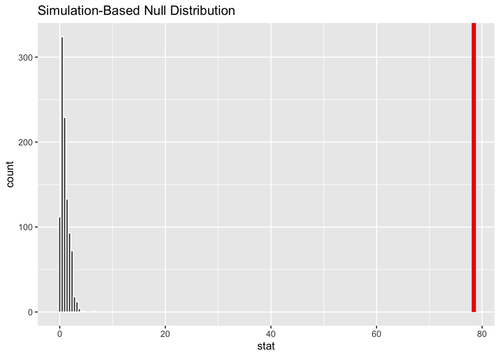

```r
library(infer) # for permutation

original.F <- aov(logMass ~ Trophic.Level, data = d) |>
  broom::tidy() |>
  filter(term == "Trophic.Level")

permuted.F <- d |>
  specify(logMass ~ Trophic.Level) |>
  hypothesize(null = "independence") |>
  generate(reps = 1000, type = "permute") |>
  calculate(stat = "F")
visualize(permuted.F) + shade_p_value(obs_stat = original.F$statistic, direction = "greater")
```

```r
p.value <- permuted.F |>
    get_p_value(obs_stat = original.F$statistic, direction = "greater")

# original p-value
paste("The original p-value is:", original.F$p.value)
```

```
[1] "The original p-value is: 3.43364926248069e-50"
```

```r
# p-value based on permutation
# p = 0, but I wonder if that is due to rounding as the original p-value is very small
paste("The p-value based on the permutation is:",p.value[["p_value"]])
```

```
[1] "The p-value based on the permutation is: 0"
```

# Challenge 2

## Step 1: Create relative beak length and relative tarsus length variables

```r
m3 <- lm(log(Beak.Length_Culmen) ~ logMass, data = d)
m4 <- lm(log(Tarsus.Length) ~ logMass, data = d)

d <- d |> mutate(RelativeBeakLength = m3$residuals) |>
  mutate(RelativeTarsusLength = m4$residuals)
```

## Step 2: Box plots of I) Relative beak length variable in relation to trophic niche and II) Relative tarsus length variable in relation to primary lifestyle

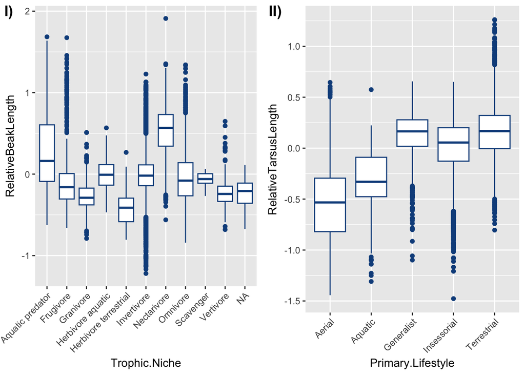

```r
box1 <- ggplot(data = d, aes(x = Trophic.Niche, y = RelativeBeakLength)) +
  geom_boxplot(color = "dodgerblue4") +
  theme(axis.text.x = element_text(angle = 45, hjust=1))

box2 <- ggplot(data = d, aes(x = Primary.Lifestyle, y = RelativeTarsusLength)) +
  geom_boxplot(color = "dodgerblue4") +
  theme(axis.text.x = element_text(angle = 45, hjust=1))

plot_grid(box1, box2, nrow = 1, labels = c("I)", "II)"))
```

## Step 3a: Association between geographic range size and migration behavior type

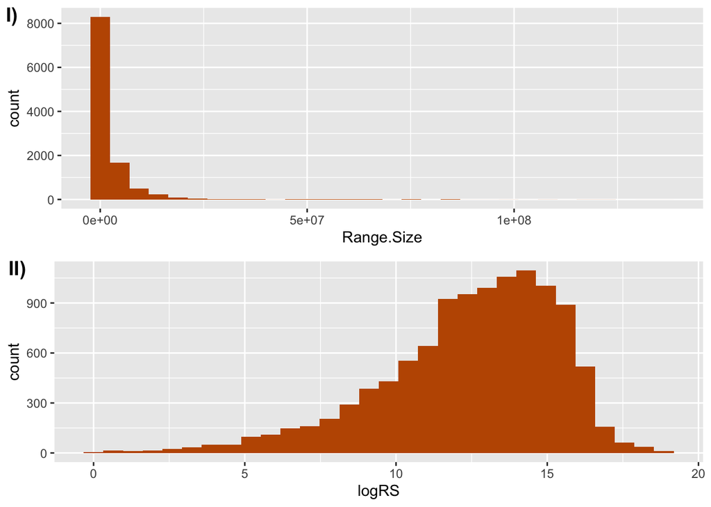

```r
migration <- d |>
  drop_na(Migration) |>
  mutate(logRS = log(Range.Size))

h1 <- ggplot(migration, aes(x = Range.Size)) +
  geom_histogram(fill= "#bf5700")

# log transform range size
h2 <- ggplot(migration, aes(x = logRS)) +
  geom_histogram(fill= "#bf5700")

plot_grid(h1, h2, nrow = 2, labels = c("I)", "II)"))
```

## Step 3b: Run models for log(Range.Size) vs. Migration

The p-values (p<0.001) indicate that there is a significant difference in the log(Range.Size) of each migration behavior type. It seems reasonable that a migratory bird would have a larger range size than a non-migratory bird.

```r
#  "3" as the reference
m5a <- lm(logRS ~ Migration, data = migration)
summary(m5a)
```

```
Call:
lm(formula = logRS ~ Migration, data = migration)

Residuals:
     Min       1Q   Median       3Q      Max
-14.5710  -1.4521   0.4357   1.9763   5.9271

Coefficients:
            Estimate Std. Error t value Pr(>|t|)
(Intercept) 14.55082    0.08896 163.568  < 2e-16 ***
Migration2  -0.73233    0.12015  -6.095 1.13e-09 ***
Migration1  -2.51702    0.09380 -26.834  < 2e-16 ***
---
Signif. codes:  0 '***' 0.001 '**' 0.01 '*' 0.05 '.' 0.1 ' ' 1

Residual standard error: 2.785 on 10934 degrees of freedom
  (49 observations deleted due to missingness)
Multiple R-squared:  0.0869,    Adjusted R-squared:  0.08674
F-statistic: 520.3 on 2 and 10934 DF,  p-value: < 2.2e-16
```

```r
# Relevel to make "2" the reference
migration$Migration <- relevel(migration$Migration, ref = "2")
m5b <- lm(logRS ~ Migration, data = migration)
summary(m5b)
```

```
Call:
lm(formula = logRS ~ Migration, data = migration)

Residuals:
     Min       1Q   Median       3Q      Max
-14.5710  -1.4521   0.4357   1.9763   5.9271

Coefficients:
            Estimate Std. Error t value Pr(>|t|)
(Intercept) 13.81850    0.08076 171.099  < 2e-16 ***
Migration3   0.73233    0.12015   6.095 1.13e-09 ***
Migration1  -1.78469    0.08606 -20.737  < 2e-16 ***
---
Signif. codes:  0 '***' 0.001 '**' 0.01 '*' 0.05 '.' 0.1 ' ' 1

Residual standard error: 2.785 on 10934 degrees of freedom
  (49 observations deleted due to missingness)
Multiple R-squared:  0.0869,    Adjusted R-squared:  0.08674
F-statistic: 520.3 on 2 and 10934 DF,  p-value: < 2.2e-16
```

```r
# Relevel to make "1" the reference
migration$Migration <- relevel(migration$Migration, ref = "1")
m5c <- lm(logRS ~ Migration, data = migration)
summary(m5c)
```

```
Call:
lm(formula = logRS ~ Migration, data = migration)

Residuals:
     Min       1Q   Median       3Q      Max
-14.5710  -1.4521   0.4357   1.9763   5.9271

Coefficients:
            Estimate Std. Error t value Pr(>|t|)
(Intercept) 12.03381    0.02974  404.62   <2e-16 ***
Migration2   1.78469    0.08606   20.74   <2e-16 ***
Migration3   2.51702    0.09380   26.83   <2e-16 ***
---
Signif. codes:  0 '***' 0.001 '**' 0.01 '*' 0.05 '.' 0.1 ' ' 1

Residual standard error: 2.785 on 10934 degrees of freedom
  (49 observations deleted due to missingness)
Multiple R-squared:  0.0869,    Adjusted R-squared:  0.08674
F-statistic: 520.3 on 2 and 10934 DF,  p-value: < 2.2e-16
```

### Post-hoc Tukey HSD test

The post-hoc Tukey HSD test also indicates that there is a significant difference in log(Range.Size) between each of the migration behavior types.

```r
m5aov <- aov(logRS ~ Migration, data = migration)
(posthoc <- TukeyHSD(m5aov, which = "Migration", conf.level = 0.95))
```

```
  Tukey multiple comparisons of means
    95% family-wise confidence level

Fit: aov(formula = logRS ~ Migration, data = migration)

$Migration
         diff      lwr      upr p adj
2-1 1.7846901 1.582952 1.986428     0
3-1 2.5170168 2.297150 2.736883     0
3-2 0.7323266 0.450689 1.013964     0
```

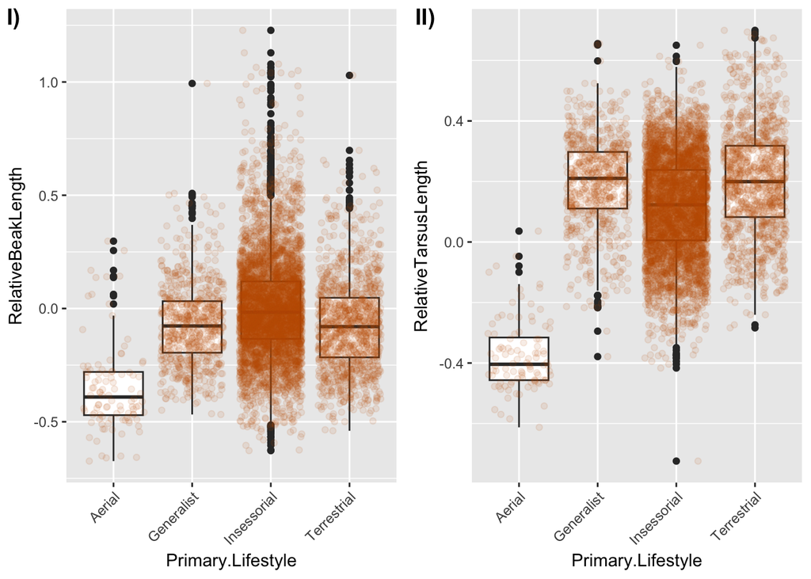

```r
songbirds <- d |> filter(Order1 == "Passeriformes")

box1 <- ggplot(data = songbirds, aes(x = Primary.Lifestyle, y = RelativeBeakLength)) +
  geom_boxplot() +
  geom_jitter(color = "#bf5700", alpha = 0.1) +
  theme(axis.text.x = element_text(angle = 45, hjust=1))

box2 <- ggplot(data = songbirds, aes(x = Primary.Lifestyle, y = RelativeTarsusLength)) +
  geom_boxplot() +
  geom_jitter(color = "#bf5700", alpha = 0.1) +
  theme(axis.text.x = element_text(angle = 45, hjust=1))

plot_grid(box1, box2, nrow = 1, labels = c("I)", "II)"))
```

## Step 4b: Models

```r
# Linear model for relative beak length vs. primary lifestyle
m6 <- lm(RelativeBeakLength ~ Primary.Lifestyle, data = songbirds)
summary(m6)
```

```
Call:
lm(formula = RelativeBeakLength ~ Primary.Lifestyle, data = songbirds)

Residuals:
    Min      1Q  Median      3Q     Max
-0.6314 -0.1380 -0.0172  0.1118  1.2241

Coefficients:
                             Estimate Std. Error t value Pr(>|t|)
(Intercept)                  -0.34950    0.02158  -16.19   <2e-16 ***
Primary.LifestyleGeneralist   0.27926    0.02306   12.11   <2e-16 ***
Primary.LifestyleInsessorial  0.35342    0.02181   16.20   <2e-16 ***
Primary.LifestyleTerrestrial  0.27924    0.02249   12.42   <2e-16 ***
---
Signif. codes:  0 '***' 0.001 '**' 0.01 '*' 0.05 '.' 0.1 ' ' 1

Residual standard error: 0.2158 on 6610 degrees of freedom
Multiple R-squared:  0.05581,   Adjusted R-squared:  0.05538
F-statistic: 130.2 on 3 and 6610 DF,  p-value: < 2.2e-16
```

```r
# Linear model for relative tarsus length vs. primary lifestyle
m7 <- lm(RelativeTarsusLength ~ Primary.Lifestyle, data = songbirds)
summary(m7)
```

```
Call:
lm(formula = RelativeTarsusLength ~ Primary.Lifestyle, data = songbirds)

Residuals:
     Min       1Q   Median       3Q      Max
-0.84084 -0.10880  0.00522  0.11805  0.53343

Coefficients:
                             Estimate Std. Error t value Pr(>|t|)
(Intercept)                  -0.37513    0.01644  -22.82   <2e-16 ***
Primary.LifestyleGeneralist   0.56932    0.01757   32.41   <2e-16 ***
Primary.LifestyleInsessorial  0.49188    0.01662   29.60   <2e-16 ***
Primary.LifestyleTerrestrial  0.57687    0.01713   33.67   <2e-16 ***
---
Signif. codes:  0 '***' 0.001 '**' 0.01 '*' 0.05 '.' 0.1 ' ' 1

Residual standard error: 0.1644 on 6610 degrees of freedom
Multiple R-squared:  0.1646,    Adjusted R-squared:  0.1642
F-statistic:   434 on 3 and 6610 DF,  p-value: < 2.2e-16
```

## Step 5: Two-way model

```r
# Two-way model
m8 <- lm(RelativeBeakLength ~ Primary.Lifestyle + Trophic.Level, data = songbirds)
summary(m8)
```

```
Call:
lm(formula = RelativeBeakLength ~ Primary.Lifestyle + Trophic.Level,
    data = songbirds)

Residuals:
     Min       1Q   Median       3Q      Max
-0.65365 -0.13329 -0.02284  0.10274  1.20180

Coefficients:
                              Estimate Std. Error t value Pr(>|t|)
(Intercept)                  -0.337362   0.021928 -15.385   <2e-16 ***
Primary.LifestyleGeneralist   0.301517   0.022582  13.352   <2e-16 ***
Primary.LifestyleInsessorial  0.375698   0.021295  17.642   <2e-16 ***
Primary.LifestyleTerrestrial  0.302119   0.021942  13.769   <2e-16 ***
Trophic.LevelHerbivore       -0.138537   0.007965 -17.393   <2e-16 ***
Trophic.LevelCarnivore       -0.012140   0.006450  -1.882   0.0599 .
---
Signif. codes:  0 '***' 0.001 '**' 0.01 '*' 0.05 '.' 0.1 ' ' 1

Residual standard error: 0.2096 on 6608 degrees of freedom
Multiple R-squared:   0.11, Adjusted R-squared:  0.1093
F-statistic: 163.4 on 5 and 6608 DF,  p-value: < 2.2e-16
```

## Step 6: Two-way model plus an interaction term (Primary.Lifestyle:Trophic.Level)

```r
m9 <- lm(RelativeBeakLength ~ Primary.Lifestyle + Trophic.Level + Primary.Lifestyle:Trophic.Level, data = songbirds)
summary(m9)
```

```
Call:
lm(formula = RelativeBeakLength ~ Primary.Lifestyle + Trophic.Level +
    Primary.Lifestyle:Trophic.Level, data = songbirds)

Residuals:
     Min       1Q   Median       3Q      Max
-0.64623 -0.12836 -0.02078  0.10070  1.21924

Coefficients: (2 not defined because of singularities)
                                                    Estimate Std. Error t value
(Intercept)                                         -0.46030    0.02582 -17.824
Primary.LifestyleGeneralist                          0.42908    0.02909  14.750
Primary.LifestyleInsessorial                         0.51353    0.02663  19.287
Primary.LifestyleTerrestrial                         0.35714    0.02210  16.162
Trophic.LevelHerbivore                              -0.16422    0.01900  -8.644
Trophic.LevelCarnivore                               0.11080    0.01550   7.150
Primary.LifestyleGeneralist:Trophic.LevelHerbivore  -0.04865    0.02882  -1.688
Primary.LifestyleInsessorial:Trophic.LevelHerbivore  0.04588    0.02120   2.164
Primary.LifestyleTerrestrial:Trophic.LevelHerbivore       NA         NA      NA
Primary.LifestyleGeneralist:Trophic.LevelCarnivore  -0.09898    0.02351  -4.210
Primary.LifestyleInsessorial:Trophic.LevelCarnivore -0.15527    0.01726  -8.996
Primary.LifestyleTerrestrial:Trophic.LevelCarnivore       NA         NA      NA
                                                    Pr(>|t|)
(Intercept)                                          < 2e-16 ***
Primary.LifestyleGeneralist                          < 2e-16 ***
Primary.LifestyleInsessorial                         < 2e-16 ***
Primary.LifestyleTerrestrial                         < 2e-16 ***
Trophic.LevelHerbivore                               < 2e-16 ***
Trophic.LevelCarnivore                              9.61e-13 ***
Primary.LifestyleGeneralist:Trophic.LevelHerbivore    0.0914 .
Primary.LifestyleInsessorial:Trophic.LevelHerbivore   0.0305 *
Primary.LifestyleTerrestrial:Trophic.LevelHerbivore       NA
Primary.LifestyleGeneralist:Trophic.LevelCarnivore  2.59e-05 ***
Primary.LifestyleInsessorial:Trophic.LevelCarnivore  < 2e-16 ***
Primary.LifestyleTerrestrial:Trophic.LevelCarnivore       NA
---
Signif. codes:  0 '***' 0.001 '**' 0.01 '*' 0.05 '.' 0.1 ' ' 1

Residual standard error: 0.2066 on 6604 degrees of freedom
Multiple R-squared:  0.1358,    Adjusted R-squared:  0.1346
F-statistic: 115.3 on 9 and 6604 DF,  p-value: < 2.2e-16
```

```r
# Another way to do this would be:
# m9 <- lm(RelativeBeakLength ~ Primary.Lifestyle + Primary.Lifestyle*Trophic.Level, data = songbirds)
```

## Step 7: Interaction plot

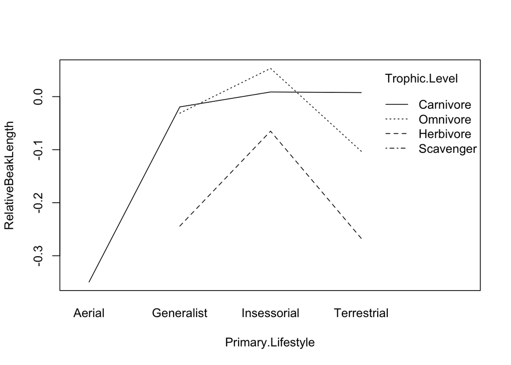

```r
interaction.plot(x.factor = songbirds$Primary.Lifestyle, xlab = "Primary.Lifestyle", trace.factor = songbirds$Trophic.Level, trace.label = "Trophic.Level",
    response = songbirds$RelativeBeakLength, fun = base::mean, ylab = "RelativeBeakLength")
```

## Step 8: Checking if the data meet the primary assumptions for standard linear regression and ANOVA

```r
#logRS ~ Migration
stats1 <- d |>
    group_by(Trophic.Level) |>
    summarize(`mean(logMass)` = mean(logMass), `sd(logMass)` = sd(logMass))

stats2 <- d |>
    group_by(Migration) |>
    summarize(`mean(logMass)` = mean(logMass), `sd(logMass)` = sd(logMass))

stats3 <- d |>
    group_by(Trophic.Level) |>
    summarize(`mean(RelativeBeakLength)` = mean(RelativeBeakLength), `sd(RelativeBeakLength)` = sd(RelativeBeakLength))

stats4 <- d |>
    group_by(Primary.Lifestyle) |>
    summarize(`mean(RelativeTarsusLength)` = mean(RelativeTarsusLength), `sd(RelativeTarsusLength)` = sd(RelativeTarsusLength))

stats5 <- songbirds |>
    group_by(Trophic.Level) |>
    summarize(`mean(RelativeBeakLength)` = mean(RelativeBeakLength), `sd(RelativeBeakLength)` = sd(RelativeBeakLength))

# check that variances are roughly equal (ratio of max/min is <2)
paste("logMass ~ Trophic.Level:", max(stats1$`sd(logMass)`)/min(stats1$`sd(logMass)`))
```

```
[1] "logMass ~ Trophic.Level: 2.48500040589004"
```

```r
paste("logMass ~ Migration:", max(stats2$`sd(logMass)`)/min(stats2$`sd(logMass)`))
```

```
[1] "logMass ~ Migration: 1.29207744733204"
```

```r
paste("RelativeBeakLength ~ Trophic.Level:", max(stats3$`sd(RelativeBeakLength)`)/min(stats3$`sd(RelativeBeakLength)`))
```

```
[1] "RelativeBeakLength ~ Trophic.Level: 4.83362115982049"
```

```r
paste("RelativeTarsusLength ~ Primary.Lifestyle:", max(stats4$`sd(RelativeTarsusLength)`)/min(stats4$`sd(RelativeTarsusLength)`))
```

```
[1] "RelativeTarsusLength ~ Primary.Lifestyle: 1.65658428505851"
```

```r
paste("RelativeBeakLength ~ Trophic.Level (songbirds):", max(stats5$`sd(RelativeBeakLength)`)/min(stats5$`sd(RelativeBeakLength)`))
```

```
[1] "RelativeBeakLength ~ Trophic.Level (songbirds): 1.33619408884105"
```